# Introduction to Linear Regression

Zachary Palmore

2020-11-01

```r
library(tidyverse)
library(openintro)
library(statsr)
```

### Pre-Lab

```r
data(hfi)
```

### Exercise 1

What are the dimensions of the dataset?

There are 1,458 rows and 123 columns.

```r
glimpse(hfi)
```

```
## Rows: 1,458
## Columns: 123
## $ year                               <dbl> 2016, 2016, 2016, 2016, 2016, 20...
## $ ISO_code                           <chr> "ALB", "DZA", "AGO", "ARG", "ARM...
## $ countries                          <chr> "Albania", "Algeria", "Angola", ...
## $ region                             <chr> "Eastern Europe", "Middle East &...
## $ pf_rol_procedural                  <dbl> 6.661503, NA, NA, 7.098483, NA, ...
## $ pf_rol_civil                       <dbl> 4.547244, NA, NA, 5.791960, NA, ...
## $ pf_rol_criminal                    <dbl> 4.666508, NA, NA, 4.343930, NA, ...
## $ pf_rol                             <dbl> 5.291752, 3.819566, 3.451814, 5....
## $ pf_ss_homicide                     <dbl> 8.920429, 9.456254, 8.060260, 7....
## $ pf_ss_disappearances_disap         <dbl> 10, 10, 5, 10, 10, 10, 10, 10, 1...
## $ pf_ss_disappearances_violent       <dbl> 10.000000, 9.294030, 10.000000, ...
## $ pf_ss_disappearances_organized     <dbl> 10.0, 5.0, 7.5, 7.5, 7.5, 10.0, ...
## $ pf_ss_disappearances_fatalities    <dbl> 10.000000, 9.926119, 10.000000, ...
```

[output cut: 110 more lines]

### Exercise 2

What type of plot would you use to display the relationship between the personal freedom score, pf_score, and one of the other numerical variables? Plot this relationship using the variable pf_expression_control as the predictor. Does the relationship look linear? If you knew a country’s pf_expression_control, or its score out of 10, with 0 being the most, of political pressures and controls on media content, would you be comfortable using a linear model to predict the personal freedom score?

To plot two numerical variables you would use a scatter plot. This relationship looks linear. It exhibits a positive trend in pf_score as pf_expression_control increases. I would be reasonably comfortable using a linear model to predict the personal freedom score of a country from the pf_expression_control score because the data are well-correlated and the sample is large enough that we have a good representative distribution.

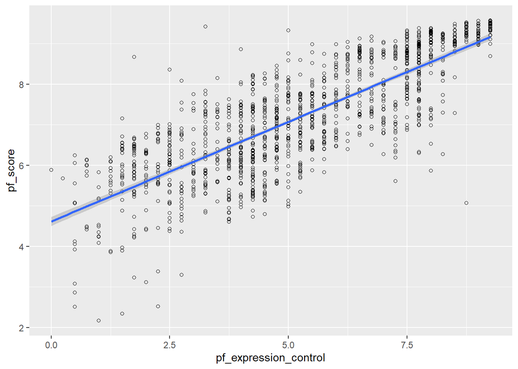

```r
ggplot(hfi, aes(x = pf_expression_control, y = pf_score)) + geom_point(shape=1) + geom_smooth(method = "lm")
```

```r
hfi %>%
  summarise(cor(pf_expression_control, pf_score, use = "complete.obs"))
```

```
## # A tibble: 1 x 1
##   `cor(pf_expression_control, pf_score, use = "complete.obs")`
##                                                          <dbl>
## 1                                                        0.796
```

```r
cor.test(hfi$pf_expression_control, hfi$pf_score)
```

```
##
##  Pearson's product-moment correlation
##
## data:  hfi$pf_expression_control and hfi$pf_score
## t = 48.847, df = 1376, p-value < 2.2e-16
## alternative hypothesis: true correlation is not equal to 0
## 95 percent confidence interval:
##  0.7762265 0.8149248
## sample estimates:
##       cor
## 0.7963894
```

### Exercise 3

Looking at your plot from the previous exercise, describe the relationship between these two variables. Make sure to discuss the form, direction, and strength of the relationship as well as any unusual observations.

The relationship is strong, positive, and linear. Its form exhibits a positive upward trend. The pf_score increases as pf_expression_control increases. There are a small number of unusual observations but it is a very small proportion of the data overall.

### Exercise 4

Using plot_ss, choose a line that does a good job of minimizing the sum of squares. Run the function several times. What was the smallest sum of squares that you got? How does it compare to your neighbors?

After running the function several times, the results were identical each time. The sum of squares returned was 952.153. It is about the same as my “neighbors.”

```r
m1 <- lm(pf_score ~ pf_expression_control, data = hfi)
pf_expression_control <- (hfi$pf_expression_control)
pf_score <-(hfi$pf_score)
pf_data <- cbind(pf_expression_control, pf_score)
pf_data <- as.data.frame(pf_data)
pf_data <- na.omit(pf_data)
# First Run
plot_ss(x = pf_expression_control, y = pf_score, data = pf_data, showSquares = TRUE)
```

```
## Click two points to make a line.

## Call:
## lm(formula = y ~ x, data = pts)
##
## Coefficients:
## (Intercept)            x
##      4.6171       0.4914
##
## Sum of Squares:  952.153
```

```r
# Second Run
plot_ss(x = pf_expression_control, y = pf_score, data = pf_data, showSquares = TRUE)
```

```
## Click two points to make a line.

## Call:
## lm(formula = y ~ x, data = pts)
##
## Coefficients:
## (Intercept)            x
##      4.6171       0.4914
##
## Sum of Squares:  952.153
```

```r
# Third Run
plot_ss(x = pf_expression_control, y = pf_score, data = pf_data, showSquares = TRUE)
```

```
## Click two points to make a line.

## Call:
## lm(formula = y ~ x, data = pts)
##
## Coefficients:
## (Intercept)            x
##      4.6171       0.4914
##
## Sum of Squares:  952.153
```

The results of each run are identical.

### Exercises 5

Fit a new model that uses pf_expression_control to predict hf_score, or the total human freedom score. Using the estimates from the R output, write the equation of the regression line. What does the slope tell us in the context of the relationship between human freedom and the amount of political pressure on media content?

The slope tells us the direction and rate of change of the relationship between human freedom and the amount of political pressure on media content. The more pressure on media content, the lower the human freedom score. Since the score for pf_expression_control starts at 0 and goes to 10, with 0 being the most pressure, the relationship shows a positive trend on the graph.

```r
m2 <- lm(hf_score ~ pf_expression_control, data = hfi)
summary(m2)
```

```
##
## Call:
## lm(formula = hf_score ~ pf_expression_control, data = hfi)
##
## Residuals:
##     Min      1Q  Median      3Q     Max
## -2.6198 -0.4908  0.1031  0.4703  2.2933
##
## Coefficients:
##                       Estimate Std. Error t value Pr(>|t|)
## (Intercept)           5.153687   0.046070  111.87   <2e-16 ***
## pf_expression_control 0.349862   0.008067   43.37   <2e-16 ***
## ---
## Signif. codes:  0 '***' 0.001 '**' 0.01 '*' 0.05 '.' 0.1 ' ' 1
##
## Residual standard error: 0.667 on 1376 degrees of freedom
##   (80 observations deleted due to missingness)
## Multiple R-squared:  0.5775, Adjusted R-squared:  0.5772
## F-statistic:  1881 on 1 and 1376 DF,  p-value: < 2.2e-16
```

```r
hfi %>%
  summarise(cor(pf_expression_control, hf_score, use = "complete.obs"))
```

```
## # A tibble: 1 x 1
##   `cor(pf_expression_control, hf_score, use = "complete.obs")`
##                                                          <dbl>
## 1                                                        0.760
```

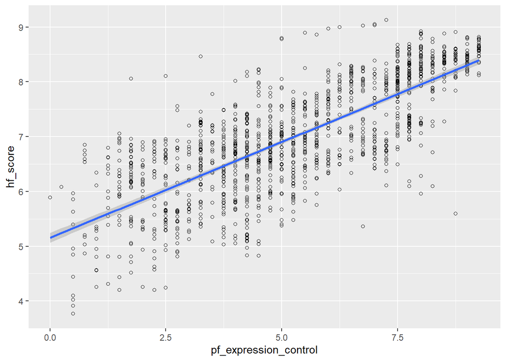

```r
ggplot(hfi, aes(x = pf_expression_control, y = hf_score)) + geom_point(shape=1) + geom_smooth(method = "lm")
```